# HW1

Citation: stackoverflow.com

Collaborators: No collaborators for coding

# Summary

We are going to produce an R package with functions with documentation, error messages, and tests (extra credit). The application is functionality to visualize and process data and estimates on family planning worldwide. Note that we already worked with the estimates in Intermediate R, HW1. Relevant code and functions from that HW are included in this Rmd in the section below, followed by the exercises for this HW.

```r
library(tidyverse)
library(readxl)
library(testthat)
library(assertthat)
library(devtools)
#knitr::opts_chunk$set(include = FALSE)
```

# Starter code for visualizing family planning estimates (from Intermediate R, HW1)

In HW1, we worked with table Model-based_estimates_Countries_2019.xlsx from https://www.un.org/en/development/desa/population/publications/dataset/contraception/data/Table_Model-based_estimates_Countries_2019.xlsx#Main, which contains estimates of modern contraceptive use (mCPR) among married women in the sheet “FP Indicators”. In this HW, we are using the processed version of this data set stored in est.csv, with

- Country or area = country name
- iso = country iso code
- Year = the reference year that the estimate refers to
- Median = point estimate of modern use among married women, in percentage
- L95 U95 = lower and upper bounds of 95% uncertainty intervals, respectively.
- L80 U80 = lower and upper bounds of 80% uncertainty intervals, respectively.

In HW1, we wrote code to produce the plot below, which shows mCPR (%) among married women against time in Afghanistan (country iso code 4), lines are median estimates. I name the plotting here plot_cp_hw1 to avoid confusion/conflicts with the function that you will store in your package.

```r
est <- read_csv("est.csv")
```

```r
# note: just adding _hw1 to the function name here to not get confused with the function
# that you will add to your package (which will be called plot_cp).
plot_cp_hw1 <- function(est, iso_code) {
  est2 <- est %>%
    filter(iso == iso_code)

  est2 %>%
    ggplot(aes(x = Year, y = Median)) +
    geom_line() +
    geom_smooth(
      stat = "identity",
      aes(ymax = U95, ymin = L95)
    ) +
    labs(x = "Time", y = "Modern use (%)", title = est2$`Country or area`[1])
}
```

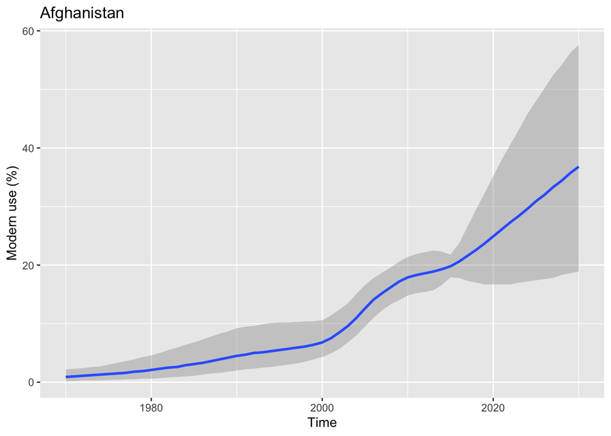

```r
plot_cp_hw1(est, iso_code = 4)
```